# Sentiment-Analysis

Deepanshu Goyal

December 18, 2019

```r
rm(list=ls())
source('https://raw.githubusercontent.com/deepanshu-goyal/Text-Analytics/master/Common_Functions.R')

if (!require(qdap)) {install.packages("qdap")}
if(!require(textdata)) {install.packages("textdata")}
if(!require(ggraph)) {install.packages("ggraph")}
if(!require(ldatuning)) {install.packages("ldatuning")}
if (!require(udpipe)){install.packages("udpipe")}

library(qdap)
library(sentimentr)
library(tidytext)
library(ggraph)
library(igraph)
library(topicmodels)
library(ldatuning)
library(udpipe)
```

## Step 1: Read data from csv file and seperate reviews for Seltos, Compass & Hector

```r
setwd(getwd())
data = read.csv('https://raw.githubusercontent.com/deepanshu-goyal/Text-Analytics/master/FinalReview.csv', header = TRUE,sep = ',')

seltos = data %>% filter(Brand=="Kia Seltos")
compass = data %>% filter(Brand =="Jeep Compass")
hector = data %>% filter(Brand== "MG Hector")
```

## Random sample 400 reviews for each car type

Random sample 400 reviews for each car, this will help in comparative analysis.We have used sample without replacement to get one review only once.

```r
seltos_sample = sample_n(seltos, 400, replace = FALSE)
compass_sample = sample_n(compass, 400, replace = FALSE)
hector_sample = sample_n(hector, 400, replace = FALSE)


final_df = bind_rows(seltos_sample,compass_sample,hector_sample)


review_df = data_frame(brand = tolower(as.character(final_df$Brand)),review = tolower(as.character(final_df$Review)))
review_dtm = create_dtm(final_df)
review_sent = get_sentences(review_df)
review_sent$topic = NA
```

## Step 2: Find out key Features/Topics in a corpus

Option1: Using word frequency, bigrams & COG graphs Option2: Using Nouns or Noun Phrases Option3: using Topic modeling techniques such as LDA Option4: using clustering technique - k means

Option1: Use bigrams & graphs (COG, igraph)

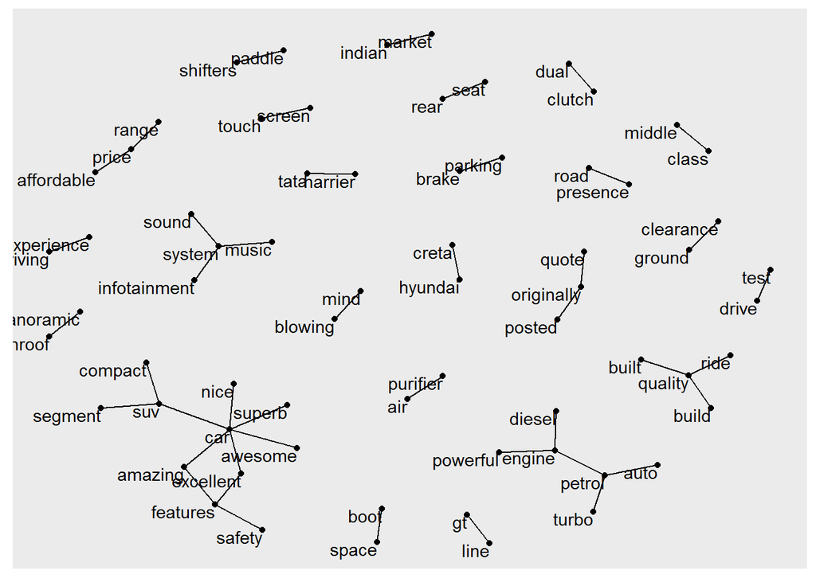

```r
#COG for all the reviews
review_bigram = create_bigram(final_df)

create.graph(review_bigram,10)
```

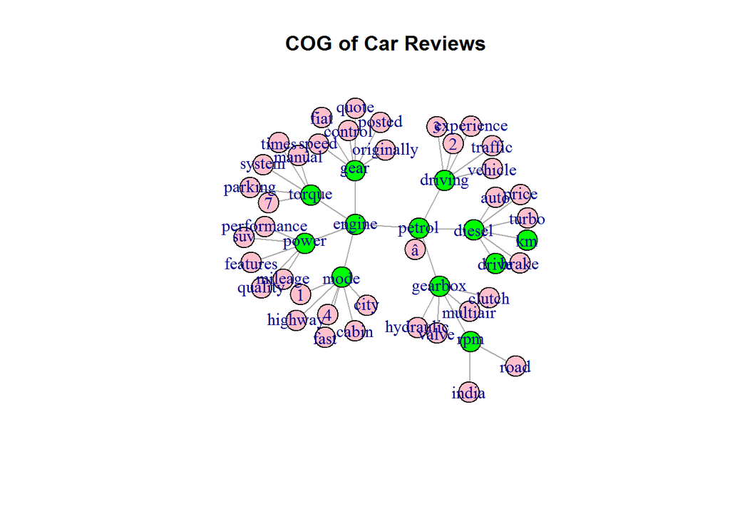

```r
distill.cog(review_dtm, 'COG of Car Reviews',12)
```

Option2: Feature extraction using Nouns or Nouns Phrases

```r
#ud_model_english <- udpipe_download_model(language = "english")

english_model = udpipe_load_model("./english-ewt-ud-2.4-190531.udpipe")

data_nlp = udpipe_annotate(english_model,x=review_df$review)

data_nlp = as.data.frame(data_nlp)
data_nlp$tag = as_phrasemachine(data_nlp$upos, type = 'upos')
head(data_nlp)
```

```
##   doc_id paragraph_id sentence_id
## 1   doc1            1           1
## 2   doc1            1           1
## 3   doc1            1           1
## 4   doc1            1           1
## 5   doc1            1           1
## 6   doc1            1           1
##                                                      sentence token_id
## 1 kia seltos is an excellent looking car with great features.        1
## 2 kia seltos is an excellent looking car with great features.        2
## 3 kia seltos is an excellent looking car with great features.        3
## 4 kia seltos is an excellent looking car with great features.        4
## 5 kia seltos is an excellent looking car with great features.        5
## 6 kia seltos is an excellent looking car with great features.        6
##       token     lemma upos xpos
```

[output cut: 20 more lines]

```r
#noun_phrase = keywords_phrases(x = data_nlp$tag,term = tolower(data_nlp$token),
#                                   pattern = "(A|N)*N(P+D*(A|N)*N)*",
#                                   is_regex = TRUE, detailed = FALSE)

#noun_phrase = subset(noun_phrase,ngram>1 & freq>1)
#head(noun_phrase,20)
```

```r
data_noun = data_nlp %>% subset(., upos %in% 'NOUN')
top_noun = txt_freq(data_noun$lemma)

values = c('kia','seltos', 'mg','hector','jeep','compass')
top_noun = top_noun %>% filter(!key %in% values)

head(top_noun,20)
```

```
##           key freq  freq_pct
## 1         car 1380 8.3676934
## 2     feature  441 2.6740238
## 3      engine  228 1.3824885
## 4      petrol  207 1.2551540
## 5       price  201 1.2187727
## 6         suv  188 1.1399466
## 7       selto  163 0.9883580
## 8     quality  149 0.9034683
## 9     segment  143 0.8670871
## 10       look  131 0.7943245
## 11     design  124 0.7518797
## 12     diesel  121 0.7336891
## 13    vehicle  116 0.7033713
## 14 experience  113 0.6851807
## 15      quote  107 0.6487994
## 16       road  104 0.6306088
## 17      drive  103 0.6245452
## 18    mileage   98 0.5942275
## 19     system   97 0.5881640
## 20    variant   88 0.5335920
```

```r
data_cooc = cooccurrence(x = data_nlp$lemma,
                           relevant =  data_nlp$upos %in% c('NOUN'))

data_cooc = data_cooc %>% filter(!term1 %in% values) %>% filter(!term2 %in% values)
head(data_cooc,20)
```

```
##      term1      term2 cooc
## 1    price      range   44
## 2     test      drive   28
## 3  driving experience   24
## 4   safety    feature   21
## 5   diesel     engine   20
## 6     boot      space   19
## 7   ground  clearance   18
## 8   petrol     engine   17
## 9    build    quality   17
## 10     air   purifier   16
## 11   music     system   14
## 12     suv        car   14
## 13   sound     system   14
## 14    ride    quality   13
## 15     suv    segment   13
## 16    road   presence   12
## 17 parking      brake   12
## 18  petrol       auto   11
## 19   voice    command   11
## 20    tata    harrier   10
```

```r
data_co = cooccurrence(x = subset(data_nlp, upos %in% c('NOUN')),
                        term = 'lemma',
                        group = c("doc_id"))
data_co = data_co %>% filter(!term1 %in% values) %>% filter(!term2 %in% values)

head(data_co,20)
```

```
##      term1      term2 cooc
## 1      car    feature  835
## 2      car     engine  509
## 3      car     petrol  458
## 4      car      price  431
## 5   diesel     petrol  405
## 6   engine     petrol  397
## 7   engine    gearbox  360
## 8      car      selto  335
## 9      car     diesel  325
## 10  diesel     engine  306
## 11  engine       gear  292
## 12 gearbox     petrol  289
## 13     car        suv  283
## 14     car experience  281
## 15     car    quality  271
## 16  engine       mode  238
## 17     car    segment  237
## 18  engine     torque  226
## 19    gear    gearbox  224
## 20     car       time  224
```

option3: Find topics using topic modeling - LDA

```r
result = ldatuning::FindTopicsNumber(
  review_dtm,
  topics = seq(from = 2, to = 20, by = 1),
  metrics = c("Griffiths2004", "CaoJuan2009", "Arun2010", "Deveaud2014"),
  method = "Gibbs",
  control = list(seed = 77),
  mc.cores = 2L,
  verbose = TRUE
)
```

```
## fit models... done.
## calculate metrics:
##   Griffiths2004... done.
##   CaoJuan2009... done.
##   Arun2010... done.
##   Deveaud2014... done.
```

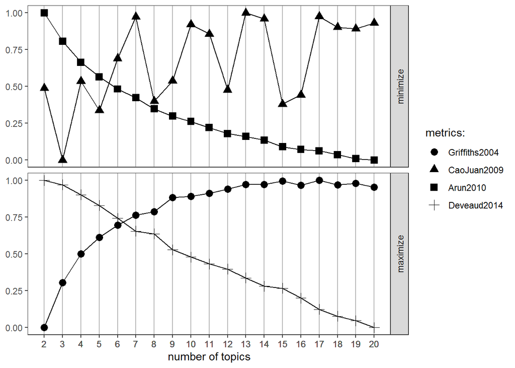

```r
ldatuning::FindTopicsNumber_plot(result)
```

```r
#find topics from consolidated data (Seltos, Jeep, Hector)
find_topics(review_dtm,12)
```

```
## # A tibble: 120 x 3
##    topic term       beta
##    <int> <chr>     <dbl>
##  1     1 nice     0.0269
##  2     1 awesome  0.0217
##  3     1 suv      0.0206
##  4     1 segment  0.0172
##  5     1 powerful 0.0161
##  6     1 interior 0.0147
##  7     1 design   0.0134
##  8     1 harrier  0.0121
##  9     1 creta    0.0116
## 10     1 india    0.0108
## # ... with 110 more rows
```

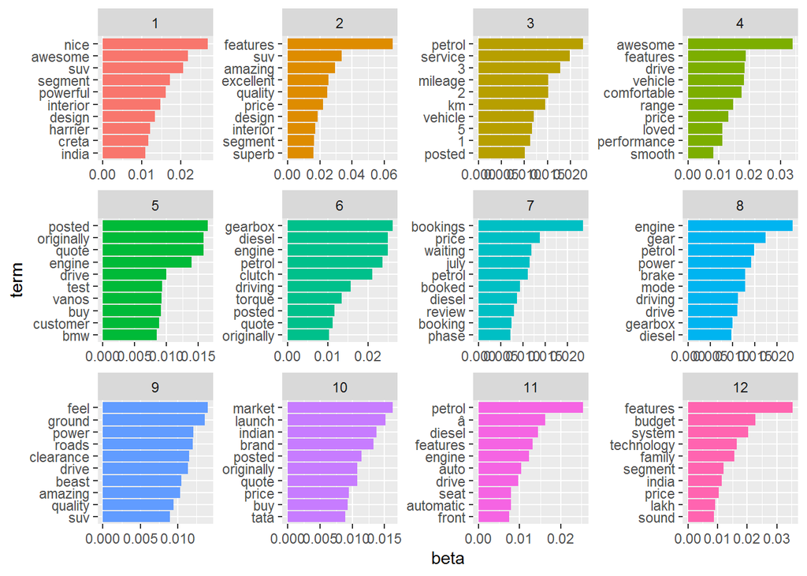

```
## # A tibble: 939 x 3
##    document         topic gamma
##    <chr>            <int> <dbl>
##  1 jeep compass_102     1 0.820
##  2 jeep compass_122     1 0.635
##  3 jeep compass_129     1 0.946
##  4 jeep compass_136     1 0.788
##  5 jeep compass_180     1 0.588
##  6 jeep compass_208     1 0.485
##  7 jeep compass_247     1 0.954
##  8 jeep compass_3       1 0.697
##  9 jeep compass_33      1 0.274
## 10 jeep compass_366     1 0.855
## # ... with 929 more rows
```

## Step 3: Choose Features/Topics

```r
keywords = c('ground clearance','price range','design','petrol engine','diesel engine','sound','clutch','service',
             'interior','driving experience','sunroof','mileage','build quality','safety','boot space', 'gearbox',
             'seats','ride quality','air purifier','power')


for (feature in keywords){
      review_sent$topic = ifelse(grepl(feature,review_sent$review),feature,review_sent$topic)
    }

review_filter = review_sent[!is.na(review_sent$topic),]

review_bow = review_filter %>% group_by(brand) %>% mutate(doc_id=row_number()) %>% ungroup() %>% unnest_tokens(word,review)


#Filtered reviews for each car type
seltos_filter = review_filter %>% filter(brand=='kia seltos') %>% mutate(element_id=row_number()) %>%
                select(element_id, brand,review,topic)
seltos_review = tolower(as.character(seltos_filter$review))

compass_filter = review_filter %>% filter(brand=='jeep compass') %>% mutate(element_id=row_number()) %>%
                select(element_id, brand,review,topic)
compass_review = tolower(as.character(compass_filter$review))

hector_filter = review_filter %>% filter(brand=='mg hector') %>% mutate(element_id=row_number()) %>%
                select(element_id, brand,review,topic)
hector_review = tolower(as.character(hector_filter$review))
```

## Step 4: Score each document usig standard dictionary, QDAP(Princeton dictionary) & SentimentR (Lexicon & Valence shifter)

Type 1: Using Dictionary ( bing, afinn & nrc)

```r
afinn = get_sentiments("afinn")
bing =  get_sentiments("bing")
nrc = get_sentiments("nrc")
```

## Scoring using BING dictionary i.e. difference of postive & negative words in each document. Find out the average for the entire corpus

```r
#Select document based on feature
bing_score = review_bow %>% inner_join(bing) %>% count(brand,element_id,sentiment) %>% spread(sentiment,n,fill = 0) %>%                group_by(brand,element_id) %>% summarise(sentiment=positive-negative)
# Overall keyword based score
overall_score1 = inner_join(bing_score,review_filter,by=c("brand","element_id")) %>% group_by(brand,topic) %>% summarise(cov_score = mean(sentiment)/sd(sentiment)) %>% spread(topic,cov_score, fill = 0)
overall_score1
```

```
## # A tibble: 3 x 21
## # Groups:   brand [3]
##   brand `air purifier` `boot space` `build quality` clutch design
##   <chr>          <dbl>        <dbl>           <dbl>  <dbl>  <dbl>
## 1 jeep~           0            0              1.25   0.559  0.476
## 2 kia ~           1.97         1.60           0.537  1.44   1.44
## 3 mg h~           0            1.40           0.567 -0.183  1.08
## # ... with 15 more variables: `diesel engine` <dbl>, `driving
## #   experience` <dbl>, gearbox <dbl>, `ground clearance` <dbl>,
## #   interior <dbl>, mileage <dbl>, `petrol engine` <dbl>, power <dbl>,
## #   `price range` <dbl>, `ride quality` <dbl>, safety <dbl>, seats <dbl>,
## #   service <dbl>, sound <dbl>, sunroof <dbl>
```

```r
#Overall Score
score_bing = bing_score %>% group_by(brand) %>% summarise(mean_Score = mean(sentiment), sd_score = sd(sentiment),cov_score = mean_Score/sd_score)
score_bing
```

```
## # A tibble: 3 x 4
##   brand        mean_Score sd_score cov_score
##   <chr>             <dbl>    <dbl>     <dbl>
## 1 jeep compass       2.15     3.33     0.646
## 2 kia seltos         3.20     2.56     1.25
## 3 mg hector          2.50     2.52     0.994
```

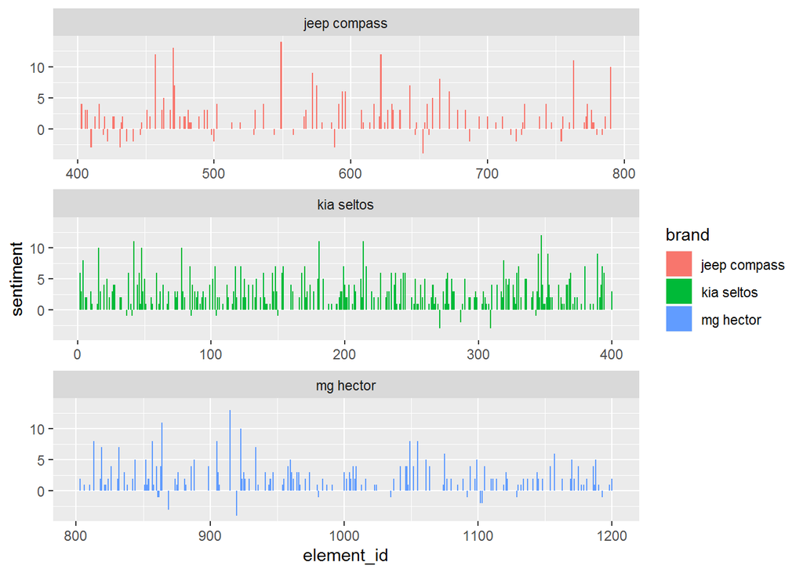

```r
ggplot(bing_score,aes(element_id,sentiment, fill=brand))+
  geom_col()+
  facet_wrap(~brand,ncol=1,scales = "free_x")
```

## Scoring using AFINN dictionary.Find out the average for the entire corpus

```r
affin_score = review_bow %>% inner_join(afinn) %>% group_by(brand,element_id) %>% summarise(sentiment = sum(value))
# Overall keyword based score
overall_score2 = inner_join(affin_score,review_filter,by=c("brand","element_id")) %>% group_by(brand,topic) %>% summarise(cov_score = mean(sentiment)/sd(sentiment)) %>% spread(topic,cov_score, fill = 0)
overall_score2
```

```
## # A tibble: 3 x 21
## # Groups:   brand [3]
##   brand `air purifier` `boot space` `build quality` clutch design
##   <chr>          <dbl>        <dbl>           <dbl>  <dbl>  <dbl>
## 1 jeep~           0            0              1.93   0.594  0.668
## 2 kia ~           2.38         1.58           0.733  1.43   1.59
## 3 mg h~           0            1.59           0.707  1.66   1.14
## # ... with 15 more variables: `diesel engine` <dbl>, `driving
## #   experience` <dbl>, gearbox <dbl>, `ground clearance` <dbl>,
## #   interior <dbl>, mileage <dbl>, `petrol engine` <dbl>, power <dbl>,
## #   `price range` <dbl>, `ride quality` <dbl>, safety <dbl>, seats <dbl>,
## #   service <dbl>, sound <dbl>, sunroof <dbl>
```

```r
#Overall Score
score_affin = affin_score %>% group_by(brand) %>% summarise(mean_Score = mean(sentiment), sd_score = sd(sentiment),cov_score = mean_Score/sd_score)
score_affin
```

```
## # A tibble: 3 x 4
##   brand        mean_Score sd_score cov_score
##   <chr>             <dbl>    <dbl>     <dbl>
## 1 jeep compass       5.37     6.38     0.842
## 2 kia seltos         7.77     6.23     1.25
## 3 mg hector          6.48     5.68     1.14
```

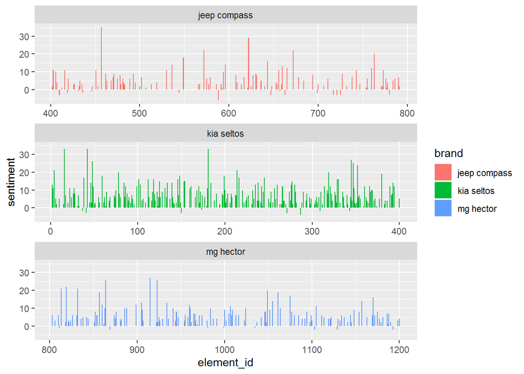

```r
ggplot(affin_score,aes(element_id,sentiment, fill=brand))+
  geom_col()+
  facet_wrap(~brand,ncol=1,scales = "free_x")
```

## Scoring using NRC dictionary.Find out the average for the entire corpus

```r
#Select document based on feature

nrc_score = review_bow %>% inner_join(nrc) %>% count(brand,element_id,sentiment) %>% spread(sentiment, n, fill=0) %>% group_by(brand, element_id) %>% summarise(sentiment = positive-negative)
# Overall keyword based score
overall_score3 = inner_join(nrc_score,review_filter,by=c("brand","element_id")) %>% group_by(brand,topic) %>% summarise(cov_score = mean(sentiment)/sd(sentiment)) %>% spread(topic,cov_score, fill = 0)
overall_score3
```

```
## # A tibble: 3 x 21
## # Groups:   brand [3]
##   brand `air purifier` `boot space` `build quality` clutch design
##   <chr>          <dbl>        <dbl>           <dbl>  <dbl>  <dbl>
## 1 jeep~           0            0               1.08  0.966  1.00
## 2 kia ~           1.25         1.00            1.03  1.27   0.943
## 3 mg h~           0            2.98            1.41  0.609  0.909
## # ... with 15 more variables: `diesel engine` <dbl>, `driving
## #   experience` <dbl>, gearbox <dbl>, `ground clearance` <dbl>,
## #   interior <dbl>, mileage <dbl>, `petrol engine` <dbl>, power <dbl>,
## #   `price range` <dbl>, `ride quality` <dbl>, safety <dbl>, seats <dbl>,
## #   service <dbl>, sound <dbl>, sunroof <dbl>
```

```r
#Overall Score
score_nrc = nrc_score %>% group_by(brand) %>% summarise(mean_Score = mean(sentiment), sd_score = sd(sentiment),cov_score = mean_Score/sd_score)
score_nrc
```

```
## # A tibble: 3 x 4
##   brand        mean_Score sd_score cov_score
##   <chr>             <dbl>    <dbl>     <dbl>
## 1 jeep compass       2.18     3.08     0.707
## 2 kia seltos         2.27     2.02     1.12
## 3 mg hector          1.97     2.00     0.983
```

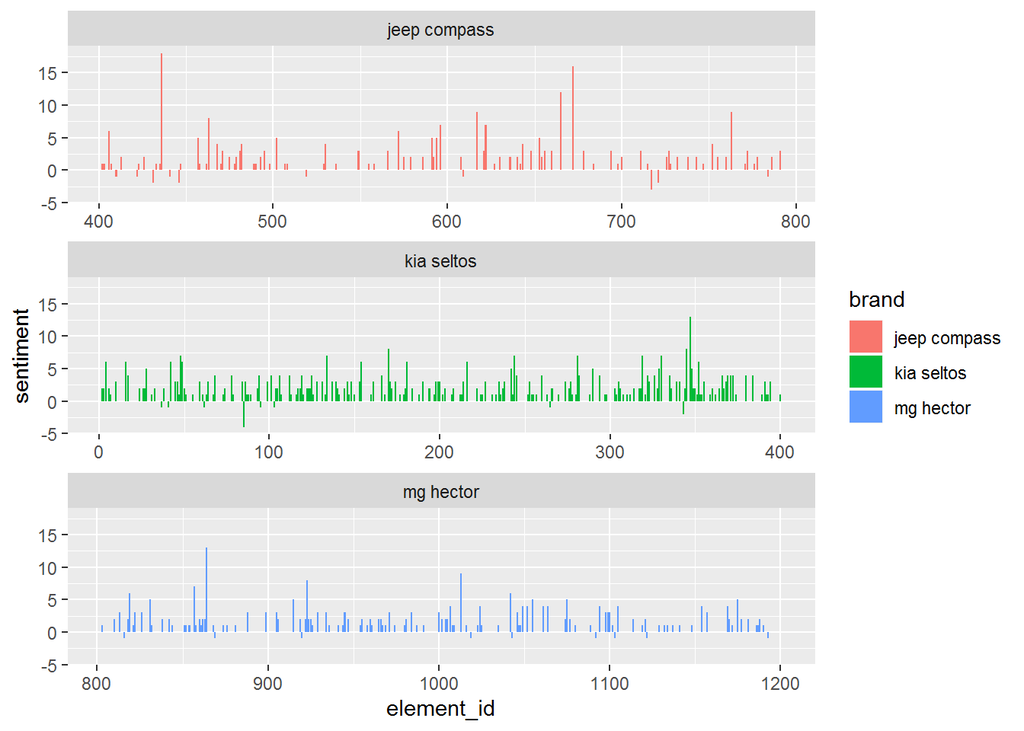

```r
ggplot(nrc_score,aes(element_id,sentiment,fill=brand))+
  geom_col()+
  facet_wrap(~brand,ncol=1,scales = "free_x")
```

## Type 2: Polarity Score using qdap

```r
#Calculate polarity score for Kia Seltos

seltos_polarity = qdap::polarity(seltos_review)
seltos_feature_score = seltos_polarity$all %>% mutate(element_id = row_number()) %>%
                select(element_id,polarity, text.var) %>% inner_join(seltos_filter,by=('element_id'))%>%
                group_by(brand, topic) %>% summarise(cov_score = mean(polarity)/sd(polarity)) %>%
                spread(topic,cov_score,fill = 0)

#Calculate polarity score for Jeep Compass

compass_polarity = qdap::polarity(compass_review)
compass_feature_score = compass_polarity$all %>% mutate(element_id = row_number()) %>%
                select(element_id,polarity, text.var) %>% inner_join(compass_filter,by=('element_id'))%>%
                group_by(brand, topic) %>% summarise(cov_score = mean(polarity)/sd(polarity)) %>%
                spread(topic,cov_score,fill = 0)


#Calculate polarity score for MG Hector

hector_polarity = qdap::polarity(hector_review)
hector_feature_score = hector_polarity$all %>% mutate(element_id = row_number()) %>%
                select(element_id,polarity, text.var) %>% inner_join(hector_filter,by=('element_id')) %>%
                group_by(brand, topic) %>% summarise(cov_score = mean(polarity)/sd(polarity)) %>%
                spread(topic,cov_score,fill = 0)


compass_qdap = data.frame(brand="Jeep Compass", mean_score = compass_polarity$group$ave.polarity, sd_score = compass_polarity$group$sd.polarity, cov_score = compass_polarity$group$stan.mean.polarity)

seltos_qdap = data.frame(brand="Kia Seltos", mean_score = seltos_polarity$group$ave.polarity, sd_score = seltos_polarity$group$sd.polarity, cov_score = seltos_polarity$group$stan.mean.polarity)

hector_qdap = data.frame(brand="MG Hector", mean_score = hector_polarity$group$ave.polarity, sd_score = hector_polarity$group$sd.polarity, cov_score = hector_polarity$group$stan.mean.polarity)


#feature-wise score
overall_score4 = bind_rows(compass_feature_score,seltos_feature_score,hector_feature_score)
overall_score4
```

```
## # A tibble: 3 x 21
## # Groups:   brand [3]
##   brand `build quality` clutch design `diesel engine` `driving experi~
##   <chr>           <dbl>  <dbl>  <dbl>           <dbl>            <dbl>
## 1 jeep~           1.43  -0.192  0.708           0.522             1.48
## 2 kia ~           0.470  1.12   1.50            0.330             1.23
## 3 mg h~           0.573 -0.502  1.24            0                 1.17
## # ... with 15 more variables: gearbox <dbl>, `ground clearance` <dbl>,
## #   interior <dbl>, mileage <dbl>, `petrol engine` <dbl>, power <dbl>,
## #   `price range` <dbl>, `ride quality` <dbl>, safety <dbl>, seats <dbl>,
## #   service <dbl>, sound <dbl>, sunroof <dbl>, `air purifier` <dbl>, `boot
## #   space` <dbl>
```

```r
#Cummulative score
bind_rows(compass_qdap, seltos_qdap, hector_qdap)
```

```
##          brand mean_score  sd_score cov_score
## 1 Jeep Compass  0.1609129 0.4442492 0.3622132
## 2   Kia Seltos  0.4753866 0.4923087 0.9656270
## 3    MG Hector  0.3936853 0.4755348 0.8278791
```

## Type 3: Polarity Score using sentiment (lexicon:hash_sentiment_jockers_rinker & Valence Shifter:hash_valence_shifters)

```r
#Calculate sentiment score for Kia Seltos

seltos_score = sentiment(seltos_review, polarity_dt = lexicon::hash_sentiment_jockers_rinker,
               valence_shifters_dt = lexicon::hash_valence_shifters)

s_score = seltos_score %>% summarise(brand = "Kia Seltos", mean_score = mean(sentiment), sd_score = sd(sentiment), cov_score = mean_score/sd_score)

seltos_feature_score  = inner_join(seltos_filter,seltos_score,by='element_id') %>% group_by(brand,topic) %>%
                        summarise(cov_score = mean(sentiment)/sd(sentiment)) %>% spread(topic,cov_score, fill = 0)


#Calculate sentiment score for Jeep Compass

compass_score = sentiment(compass_review, polarity_dt = lexicon::hash_sentiment_jockers_rinker,
                valence_shifters_dt = lexicon::hash_valence_shifters)

c_score = compass_score %>% summarise(brand = "Jeep Compass", mean_score = mean(sentiment), sd_score = sd(sentiment), cov_score = mean_score/sd_score)


compass_feature_score = inner_join(compass_filter,compass_score,by='element_id') %>% group_by(brand,topic) %>%
                        summarise(cov_score = mean(sentiment)/sd(sentiment)) %>% spread(topic,cov_score, fill = 0)


#Calculate sentiment score for MG Hector

hector_score = sentiment(hector_review, polarity_dt = lexicon::hash_sentiment_jockers_rinker,
               valence_shifters_dt = lexicon::hash_valence_shifters)

h_score = hector_score %>% summarise(brand = "MG Hector", mean_score = mean(sentiment), sd_score = sd(sentiment), cov_score = mean_score/sd_score)


hector_feature_score = inner_join(hector_filter,hector_score,by='element_id') %>% group_by(brand,topic) %>%
                        summarise(cov_score = mean(sentiment)/sd(sentiment)) %>% spread(topic,cov_score, fill = 0)



bind_rows(c_score, s_score, h_score)
```

```
##          brand mean_score  sd_score cov_score
## 1 Jeep Compass  0.1769446 0.3880290 0.4560086
## 2   Kia Seltos  0.3975538 0.4064247 0.9781732
## 3    MG Hector  0.3375004 0.3836031 0.8798168
```

```r
overall_score5 = bind_rows(compass_feature_score,seltos_feature_score,hector_feature_score)
overall_score5
```

```
## # A tibble: 3 x 21
## # Groups:   brand [3]
##   brand `build quality` clutch design `diesel engine` `driving experi~
##   <chr>           <dbl>  <dbl>  <dbl>           <dbl>            <dbl>
## 1 jeep~            1.87 -0.298  0.881           0.703            2.20
## 2 kia ~            3.81  1.08   1.47            0.280            1.36
## 3 mg h~            1.90 -0.637  1.30         -Inf                0.982
## # ... with 15 more variables: gearbox <dbl>, `ground clearance` <dbl>,
## #   interior <dbl>, mileage <dbl>, `petrol engine` <dbl>, power <dbl>,
## #   `price range` <dbl>, `ride quality` <dbl>, safety <dbl>, seats <dbl>,
## #   service <dbl>, sound <dbl>, sunroof <dbl>, `air purifier` <dbl>, `boot
## #   space` <dbl>
```

```r
overall_score = bind_rows(overall_score1, overall_score2, overall_score3,overall_score4,overall_score5)
write.csv(overall_score,'overall.csv')
```